# Numerical Methods for PDEs (Spring 2017), Lab 11

Gustav Delius, Richard Southwell

The purpose of this short lab is to reassure everyone that the even if you have a complicated-looking system of parabolic PDEs, the forward-difference method is straightforward to apply. It only has the drawback of requiring a very small timestep. One may therefore like to later go to implicit methods, which are much more clever and tricky and can give an amazing speed-up while at the same time removing stability problems. However I recommend to always initially set up the simple forward-difference method, if only to have something simple to compare the more sophisticated methods against.

For this lab I chose the paper

Tsyganov, M.A., Brindley, J., Holden, A.V., and Biktashev, V.N. (2003). Quasisoliton Interaction of Pursuit-Evasion Waves in a Predator-Prey System. Phys. Rev. Lett. 91, 218102.

It describes the abundance $Z$ of a predator (you can think of zooplankton if you like) and an abundance $P$ of prey (phytoplankton) by the set of coupled equations
$$\begin{split}
\frac{\partial P}{\partial t} &= D\frac{\partial^2 P}{\partial x^2}
+h_- \frac{\partial}{\partial x}P\frac{\partial Z}{\partial x}
+\beta P(1-P)-Z\frac{P^2}{P^2+\nu^2},\\
\frac{\partial Z}{\partial t} &= D\frac{\partial^2 Z}{\partial x^2}
-h_+ \frac{\partial}{\partial x}Z\frac{\partial P}{\partial x}
+\gamma Z\left(\frac{P^2}{P^2+\nu^2}-w\right).
\end{split}$$

Here $D, h_-, h_+, \beta, \nu, \gamma$ are constant parameters.

If this was a proper project report we would now discuss the meaning of these terms a bit, but for now we are only interested in implementing the forward difference method for this somewhat complicated looking set of equations.

Each of the equations contains a linear second-order derivative term that we will discretize as in eq.(2.7) in the lecture notes:
$$\frac{\partial^2 P}{\partial x^2}(x_k,t_j)=
\frac{P_{k+1,j}-2P_{k,j}+P_{k-1,j}}{h^2}-O(h^2),$$
and similarly for $\partial^2 Z/\partial x^2$.

For the time derivatives we use the forward difference formula
$$\frac{\partial P}{\partial t}(x_k,t_j)=
\frac{P_{k,j+1}-P_{k,j}}{\tau}+O(\tau)$$

In order to keep a truncation error of $O(h^2)$ we use the scheme from section 2.6 in the lecture notes: we introduce points $x_{-1}$ and $x_{N+1}$ and use the central-difference formula for the derivative to translate the boundary conditions into expressions for the values of the solution at these points:
$$P_{-1,j}=P_{1,j},~~P_{N+1,j}=P_{N-1,j},
~~ Z_{-1,j}=Z_{1,j},~~Z_{N+1,j}=Z_{N-1,j},$$
This allows us to use the finite difference equations above with $k=0$ and $k=N$.

In R we like to work with entire vectors at a time rather than dealing with each $x_k$ individually. For that purpose we introduce vectors
$${\vec P}_j = \begin{pmatrix}P_{0,j}\\P_{1,j}\\\vdots\\P_{N-1,j}\\P_{N,j}\end{pmatrix},~~~
{\vec P}^+_j = \begin{pmatrix}P_{1,j}\\P_{2,j}\\\vdots\\P_{N,j}\\P_{N-1,j}\end{pmatrix},~~~
{\vec P}^-_j = \begin{pmatrix}P_{1,j}\\P_{0,j}\\\vdots\\P_{N-2,j}\\P_{N-1,j}\end{pmatrix}$$
and similarly for $Z$. This will allow us to translate the method into efficient R code below.

We choose a step size $h$ and introduce the grid points $x_k = k h$ for $k=0,\dots,N$

```r
h <- 0.1
N <- 400
x <- (0:N)*h
```

and similarly we introduce a step size $\tau$ and time grid points $t_j=j\tau$ for $j=0,\dots M$. However we do not want to save results at each time step, because there are so many of them, and so we split this as $M = M_1 M_2$ and then only save $M_1 = 100$ results.

```r
tau <- 0.1
M <- 4000
M1 <- 100
M2 <- round(M/M1)
```

We create the vector of times at which we save the results

```r
t <- (0:M1)*M2*tau
```

We initialise two matrices to hold the approximations $P_{k,j}$ and $Z_{k,j}$ to the exact solution for $k=0,\dots,N$ and $j=0,\dots,M$.

```r
wp <- matrix(0, nrow=N+1, ncol=M1+1)
wz <- matrix(0, nrow=N+1, ncol=M1+1)
```

We choose parameter values

```r
D <- 0.04
nu <- 0.07
beta <- 1
gamma <- 0.01
w <- 0.004/gamma
hp <- 0
hm <- 0
```

We determine the steady-state constant solution $(P_0,Z_0)$ to the equations. The equations for this solution are obtained by setting all derivatives equal to zero in the PDEs.

```r
P0 <- uniroot(function(P) P^2/(P^2+nu^2)-w, interval=c(0,1))$root
Z0 <- beta*P0*(1-P0)/w
```

We will choose an initial condition in which we increase the abundance to the phytoplankton abundance above its equilibrium value near the left end of the interval in order to trigger a plankton bloom there.
$$P(x,0) = P_0 + \begin{cases}0.2(\cos(4\pi x)+1) & \text{ if } x<1/4\\
0& \text{ otherwise }\end{cases}, ~~~ Z(x,0) = Z_0.$$

```r
Pn <- P0 + ifelse(x<1/4, 0.2*(cos(4*pi*x)+1), 0)
Zn <- Z0 + 0*x  # the +0*x term ensures this is a vector of the same length as x
wp[, 1] <- Pn
wz[, 1] <- Zn
```

Now we are ready to step through time and at each step update the result according to the formulae derived above. At every $M_2$-th step we save the result.

```r
for (j in 1:M1) {
  for (j2 in 1:M2) {

    P <- Pn
    Pp <- c(P[2:(N+1)], P[N])
    Pm <- c(P[2], P[1:N])

    Z <- Zn
    Zp <- c(Z[2:(N+1)], Z[N-1])
    Zm <- c(Z[2], Z[1:N])

    Pn <- P + tau * (
      D/h^2 * (Pp - 2*P + Pm) +
        hm/(2*h^2) * ((Pp+P)*(Zp-Z)-(P+Pm)*(Z-Zm)) +
        beta*P*(1-P)-Z*P^2/(P^2+nu^2)
    )

    Zn <- Z + tau * (
      D/h^2 * (Zp - 2*Z + Zm) -
        hp/(2*h^2) * ((Zp+Z)*(Pp-P)-(Z+Zm)*(P-Pm)) +
        gamma*Z*(P^2/(P^2+nu^2) - w)
    )
  }
  wp[, j+1] <- Pn
  wz[, j+1] <- Zn
}
```

Finally we make a plot of the result. Here is the prey abundance:

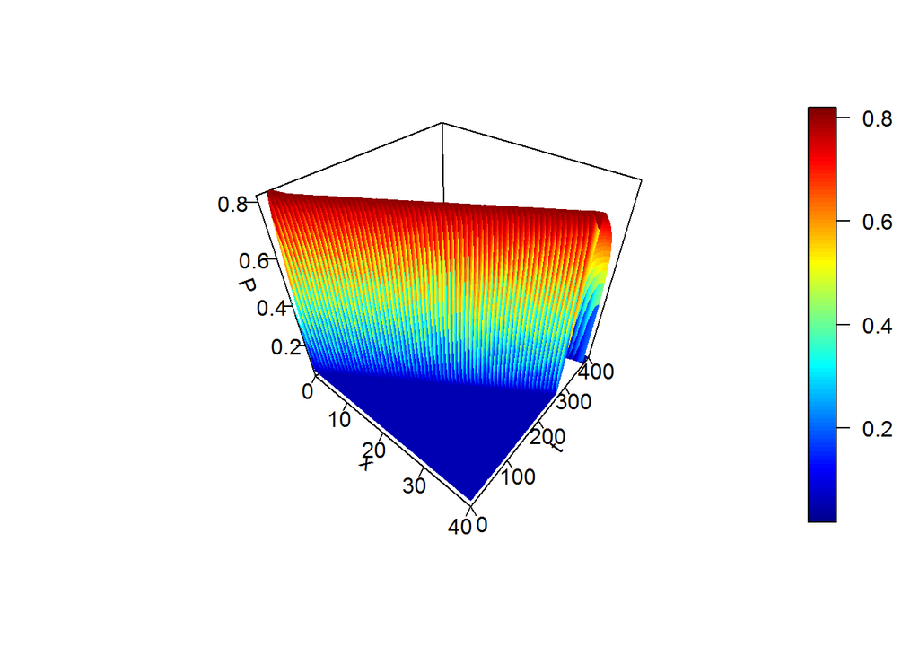

```r
library(plot3Drgl)
persp3D(x, t, wp,
        xlab="x", ylab="t", zlab="P",
        ticktype="detailed", nticks=4)
```

```r
plotrgl(lighting = TRUE, smooth = TRUE)
```

Here is the predator abundance:

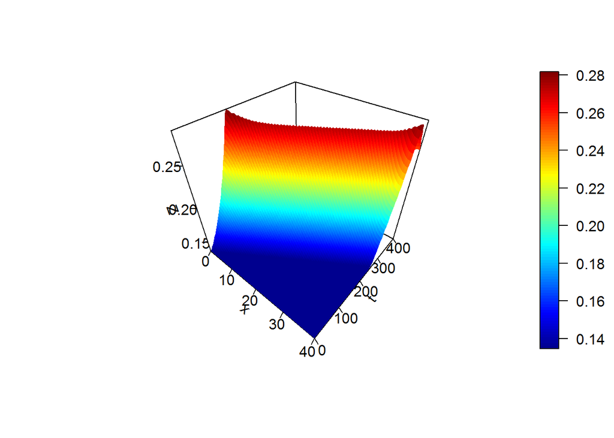

```r
persp3D(x, t, wz,
        xlab="x", ylab="t", zlab="Z",
        ticktype="detailed", nticks=4)
```

```r
plotrgl(lighting = TRUE, smooth = TRUE)
```

We choose an intermediate time and plot both abundances on a 2-d plot:

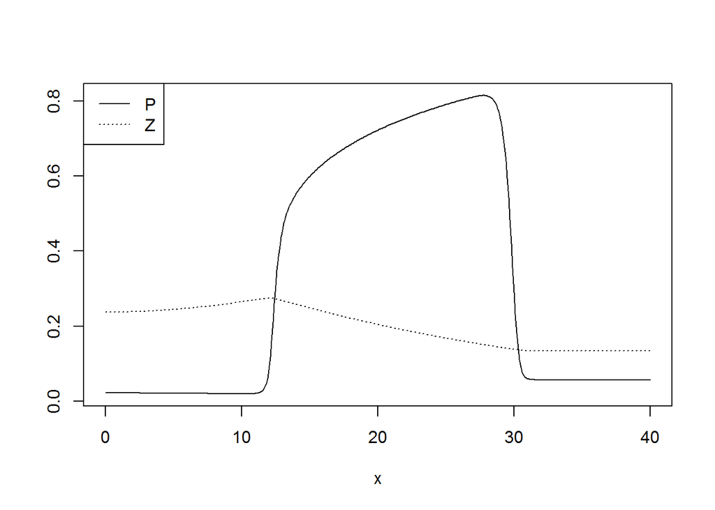

```r
plot(x, wp[, 51], type="l", ylab="")
lines(x, wz[, 51], lty="dotted")
legend("topleft", legend=c("P", "Z"), lty=c("solid", "dotted"))
```

This is similar to Figure 1(a) in the paper.

To facilitate exploration of the parameter space, we encapsulate the code we used above in a function.

```r
explicit <- function(deltaP=function(x) 0*x, deltaZ=function(x) 0*x,
                     D=0.04, nu=0.07, beta=1, gamma=0.01, w=0.4, hp=0, hm=0,
                     L=40, N=400, T=400, M=4000) {
  h <- L/N
  x <- (0:N)*h

  tau <- T/M
  M1 <- 100
  M2 <- round(M/M1)
  t <- (0:M1)*M2*tau

  wp <- matrix(0, nrow=N+1, ncol=M1+1)
  wz <- matrix(0, nrow=N+1, ncol=M1+1)

  P0 <- uniroot(function(P) P^2/(P^2+nu^2)-w, interval=c(0,1))$root
  Z0 <- beta*P0*(1-P0)/w
  Pn <- P0 + deltaP(x)
  Zn <- Z0 + deltaZ(x)
  wp[, 1] <- Pn
  wz[, 1] <- Zn

  for (j in 1:M1) {
    for (j2 in 1:M2) {

      P <- Pn
      Pp <- c(P[2:(N+1)], P[N])
      Pm <- c(P[2], P[1:N])

      Z <- Zn
      Zp <- c(Z[2:(N+1)], Z[N-1])
      Zm <- c(Z[2], Z[1:N])

      Pn <- P + tau * (
        D/h^2 * (Pp - 2*P + Pm) +
          hm/(2*h^2) * ((Pp+P)*(Zp-Z)-(P+Pm)*(Z-Zm)) +
          beta*P*(1-P)-Z*P^2/(P^2+nu^2)
      )

      Zn <- Z + tau * (
        D/h^2 * (Zp - 2*Z + Zm) -
          hp/(2*h^2) * ((Zp+Z)*(Pp-P)-(Z+Zm)*(P-Pm)) +
          gamma*Z*(P^2/(P^2+nu^2) - w)
      )
    }
    wp[, j+1] <- Pn
    wz[, j+1] <- Zn
  }
  list(x=x, t=t, P=wp, Z=wz)
}
```

We also define the perturbation from the steady-state value for $P$ that we use in the initial condition.

```r
deltaP <- function(x) ifelse(x<1/4, 0.4*(cos(4*pi*x)+1), 0)
```

We can now try to reproduce other plots from the paper by changing the value if $h_+$. Here is Figure 1(b)

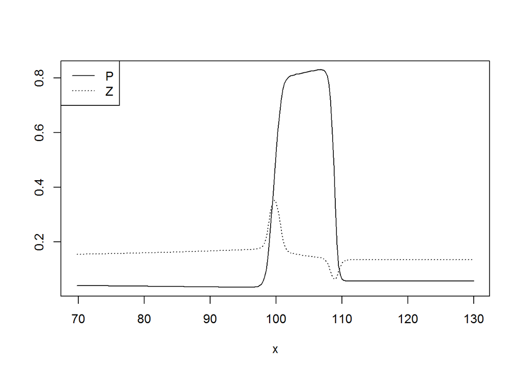

```r
sol <- explicit(deltaP=deltaP, hp=0.5, L=130, N=520, T=390, M=3000)
plot(sol$x[280:521], sol$P[280:521, 101], type="l", xlab="x", ylab="")
lines(sol$x[280:521], sol$Z[280:521, 101], lty="dotted")
legend("topleft", legend=c("P", "Z"), lty=c("solid", "dotted"))
```

And Figure 1(c):

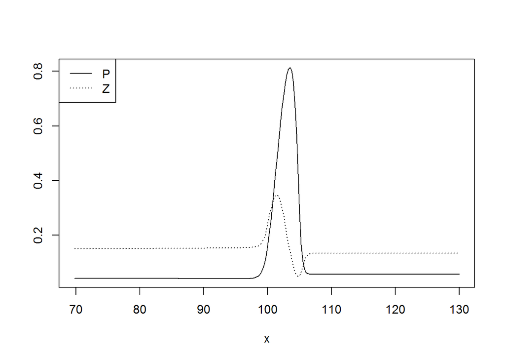

```r
sol <- explicit(deltaP=deltaP, hp=0.9, L=130, N=520, T=330, M=2800)
plot(sol$x[280:521], sol$P[280:521, 101], type="l", xlab="x", ylab="")
lines(sol$x[280:521], sol$Z[280:521, 101], lty="dotted")
legend("topleft", legend=c("P", "Z"), lty=c("solid", "dotted"))
```

However I think that the authors made a mistake. The above figure, and therefore the figure in the paper, is not a good representation of the actual solution when $h_+=0.9$. We can see that by getting a more precise solution by decreasing $\tau$ by increasing the number of time steps to $M=24000$:

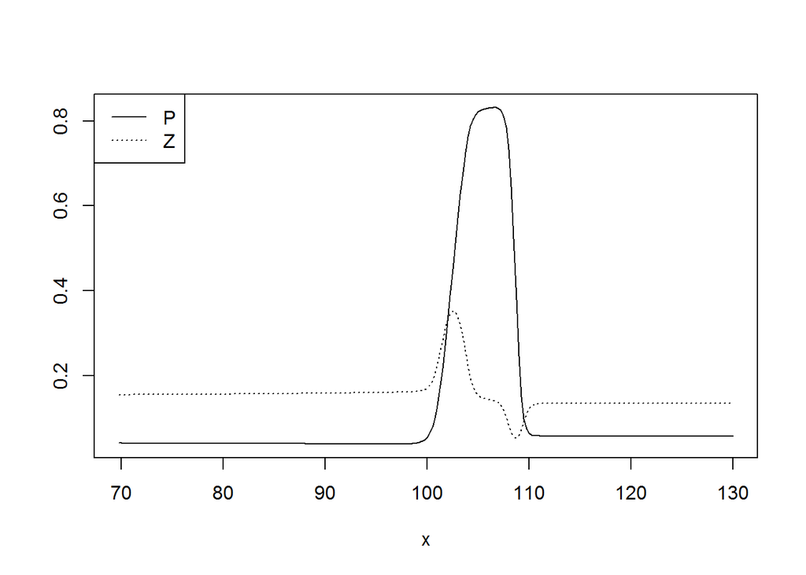

```r
sol <- explicit(deltaP=deltaP, hp=0.9, L=130, N=520, T=330, M=24000)
plot(sol$x[280:521], sol$P[280:521, 101], type="l", xlab="x", ylab="")
lines(sol$x[280:521], sol$Z[280:521, 101], lty="dotted")
legend("topleft", legend=c("P", "Z"), lty=c("solid", "dotted"))
```

However even with $M=24000$ steps there are numerical problems with the solution as we can see by making a 3d plot:

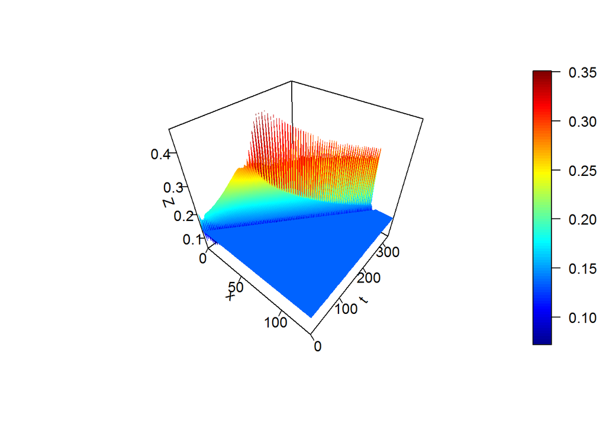

```r
persp3D(sol$x, sol$t, sol$Z,
        xlab="x", ylab="t", zlab="Z",
        ticktype="detailed", nticks=4)
```

There are rapid oscillations in the value of $Z$ in those places where $\partial P/\partial x$ is very large. Apparently the fact that $P$ can change so rapidly means that the cross-diffusion term in the equation for $Z$ requires a very small time step in our explicit method.

We could hope to improve on this by using an implicit method for the diffusion terms.